# Exploratory Data Analysis on corpora

This report is to briefly explain the exploratory data analysis carried out on set of three English text files. The report is divided into following sections:

- Getting the data
- Summarizing the data
- Sampling the data
- Tokenization
- n-gram frequency distribution
- Plan for prediction alogrithm

**Getting the data:** The data has been downloaded from the website - https://d396qusza40orc.cloudfront.net/dsscapstone/dataset/Coursera-SwiftKey.zip . Data consists of three English text files. The data is then loaded into R by using the function $readLines$.

```r
fileconn <- file("en_US.blogs.txt", "rb" )
newblogs <- readLines(fileconn, skipNul = TRUE)
close(fileconn)
fileconn <- file("en_US.news.txt", "rb")
newnews <- readLines(fileconn, skipNul = TRUE)
close(fileconn)
fileconn <- file("en_US.twitter.txt", "rb" )
newtwitter <- readLines(fileconn, skipNul = TRUE)
close(fileconn)
```

**Summarizing the data:**

- Length of the “en_US.blogs.txt”" file is 899288 lines and 37333877 words.
- Length of the “en_US.news.txt”" file is 1010242 lines and 34372491 words.
- Length of the “en_US.twitter.txt”" file is 2360148 lines and 30354351 words.

**Sampling the data:** $rbinom$ method is used to sample the data. A biased coin of 1% chance of getting head is used to sample the data. About 1% of the original text file size is thus obtained. The three sampled texts are then collectively used to analyze the word frequency distribution.

**Tokenization:** A function for $tokenization$ is written using the regular expression function $gsub$ to identify *only* the words in the text file.

**n-gram frequency distribution:** $textcnt$ function of R package $tau$ is used for analyzing the frequency distribution of n-grams. List of a few common words is removed to understand the relationship between the words in the corpora.

*1-gram frequency distribution:*

The following frequency distribution is obtained after doing 1-gram.

```
##     grams  freq
##  1:  just 30179
##  2:  said 30396
##  3:  they 32406
##  4:   all 33144
##  5:   its 35684
##  6:    so 38071
##  7:   not 41023
##  8:    we 41683
##  9:   but 47948
## 10:  have 52868
```

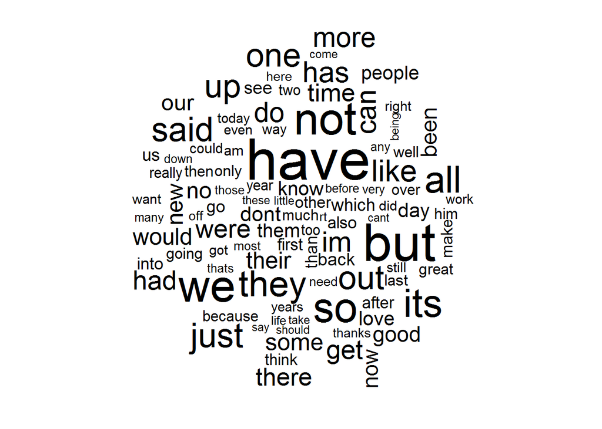

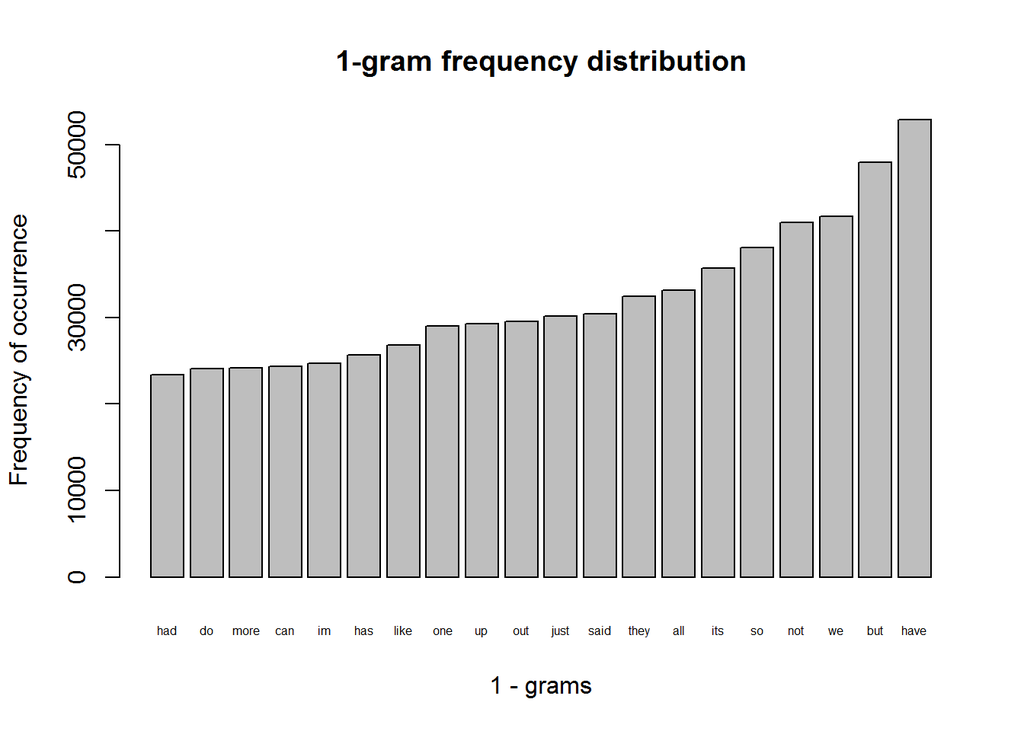

From the distribution, it is clear that words such as **have** and **but** occurs more often than other words.

*2-gram frequency distribution:*

```
##          grams freq
##  1:    its not 2008
##  2: would have 2102
##  3:  they were 2206
##  4:     im not 2482
##  5:  right now 2483
##  6:    so much 3245
##  7:    we have 3434
##  8:  more than 4115
##  9:   has been 4441
## 10:  have been 4865
```

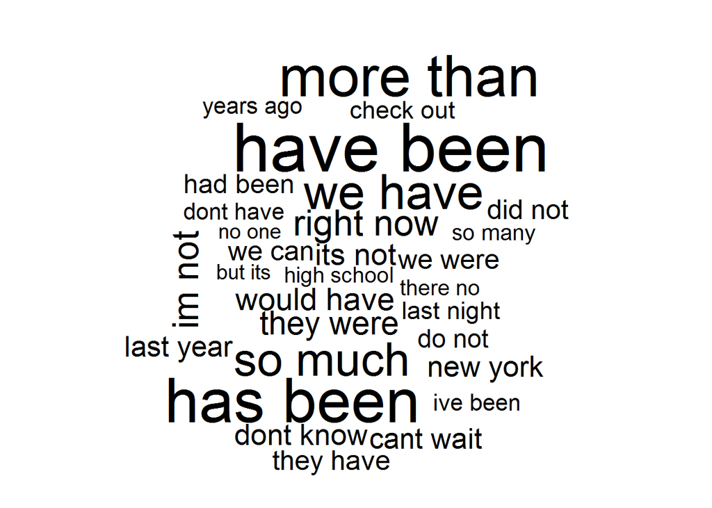

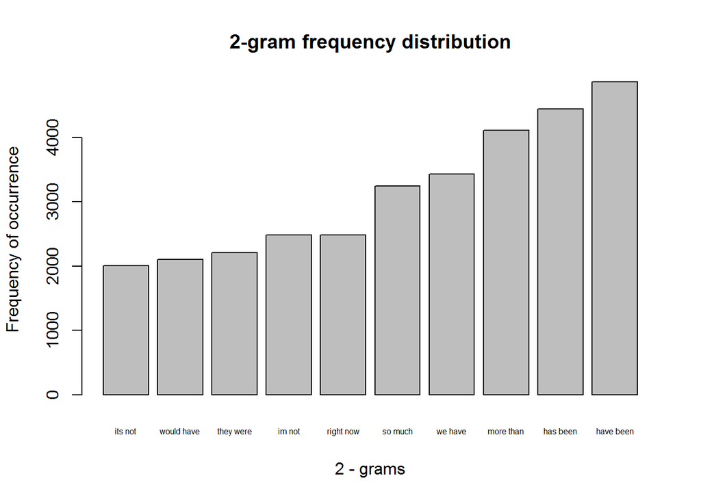

Word pairs such as **have been** and **has been** tend to occur more often than other word pairs.

*3-gram frequency distribution:*

```
##                 grams freq
##  1:    happy new year  213
##  2:      have no idea  236
##  3:     new york city  247
##  4:       let us know  258
##  5:     thank so much  265
##  6: happy mothers day  339
##  7:    thanks so much  339
##  8:     cant wait see  360
##  9:       im not sure  383
## 10:   would have been  442
```

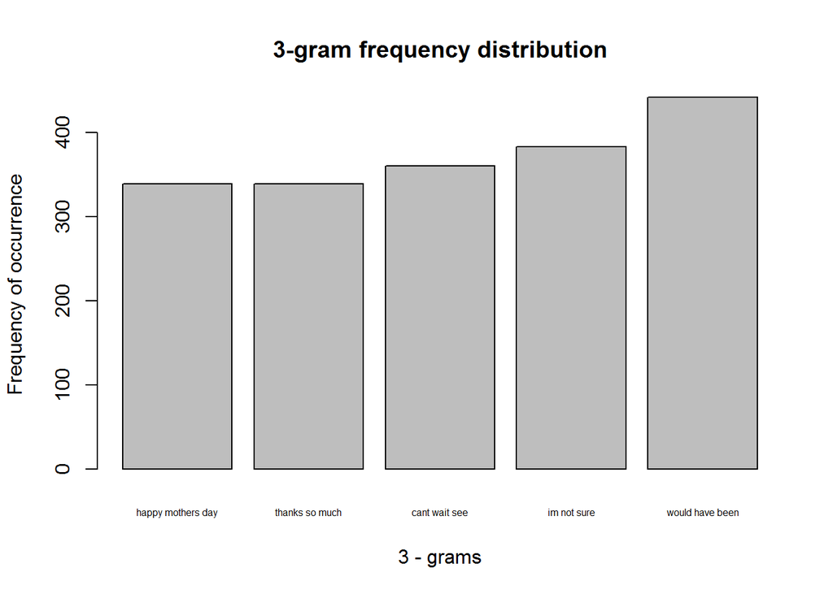

Word phrases such as **would have been** and **im not sure** occurs more often than other word phrases.

**Plan for prediction algorithm:**

- Segment the corpora data into training and test corpus
- Apply N-gram model to the training corpus (conditional probability for next word based on Markov process)
- Apply one of the techniques for unseen n-grams (Smoothing/Backoff/Good-Turing)
- Predict with the test set